# CVM: Constrained variational optimization model with factorial designs

haiyan yu

7/16/2020

3, weights for the control, not selected

# Data preperation

```r
library("roxygen2")
library("readxl")
#library("CORopt")
library("cvmfd")
library(LaplacesDemon)
library(xtable)
#########
data <-
 suppressWarnings(data <-read_excel("~/Downloads/Rpkg/CORopt/data/USyu_AB_Med0UA1c_test.xlsx"))
#summary(data)#1: over 30; 0 :less 30
ls(data)
```

```
##  [1] "admission_source_id"      "admission_type_id"
##  [3] "age"                      "discharge_disposition_id"
##  [5] "encounter_id"             "gender"
##  [7] "glyburide"                "glyburide-metformin"
##  [9] "metformin"                "num_lab_procedures"
## [11] "num_medications"          "num_patnbr"
## [13] "num_procedures"           "number_diagnoses"
## [15] "number_emergency"         "number_inpatient"
## [17] "number_outpatient"        "patient_nbr"
## [19] "race"                     "readmitted"
## [21] "time_in_hospital"
```

```r
names(data)
```

```
##  [1] "encounter_id"             "patient_nbr"
##  [3] "admission_type_id"        "discharge_disposition_id"
##  [5] "admission_source_id"      "num_patnbr"
##  [7] "race"                     "gender"
##  [9] "age"                      "time_in_hospital"
## [11] "num_lab_procedures"       "num_procedures"
## [13] "num_medications"          "number_outpatient"
## [15] "number_emergency"         "number_inpatient"
## [17] "number_diagnoses"         "metformin"
## [19] "glyburide"                "glyburide-metformin"
## [21] "readmitted"
```

```r
head(data, 1)
```

```
## # A tibble: 1 x 21
##   encounter_id patient_nbr admission_type_… discharge_dispo… admission_sourc…
##          <dbl>       <dbl>            <dbl>            <dbl>            <dbl>
## 1      7839114     5662800                1                1                7
## # … with 16 more variables: num_patnbr <dbl>, race <chr>, gender <dbl>,
## #   age <dbl>, time_in_hospital <dbl>, num_lab_procedures <dbl>,
## #   num_procedures <dbl>, num_medications <dbl>, number_outpatient <dbl>,
## #   number_emergency <dbl>, number_inpatient <dbl>, number_diagnoses <dbl>,
## #   metformin <dbl>, glyburide <dbl>, `glyburide-metformin` <dbl>,
## #   readmitted <dbl>
```

```r
nrow(data)
```

```
## [1] 15729
```

```r
df.ctl<-data[data$metformin==0 &data$glyburide==0&data$`glyburide-metformin`==0,]
nrow(df.ctl)
```

```
## [1] 9473
```

```r
#table(data$race,data$age)
table(data$age,data$readmitted)
```

```
##
##        0    1
##   1    4   28
##   2   36  119
##   3  121  349
##   4  291 1088
##   5  527 2001
##   6  812 2621
##   7 1068 3376
##   8  660 2215
##   9   37   68
```

```r
#table(data$race,data$readmitted)
datax <- data[, c(6:21)]
df.sample<-head(data[, c(6:21)][, c(4,1:3,7,12,13:15)],8)
df.samplea3<-head(data[, c(6:21)][data$`glyburide-metformin`==2, c(4,1:3,7,12,13:15)],2)
df.samplea0<-head(data[, c(6:21)][data$`glyburide-metformin`==0&data$metformin==0&data$glyburide==0, c(4,1:3,7,12,13:15)],2)
xtable(df.sample)
```

```
## % latex table generated in R 4.0.2 by xtable 1.8-4 package
## % Mon May 24 09:18:28 2021
## \begin{table}[ht]
## \centering
## \begin{tabular}{rrrlrrrrrr}
##   \hline
##  & age & num\_patnbr & race & gender & num\_procedures & number\_diagnoses & metformin & glyburide & glyburide-metformin \\
##   \hline
## 1 & 1.00 & 2.00 & 2 & 1.00 & 0.00 & 9.00 & 0.00 & 2.00 & 0.00 \\
##   2 & 1.00 & 2.00 & 2 & 1.00 & 0.00 & 9.00 & 2.00 & 0.00 & 0.00 \\
##   3 & 1.00 & 2.00 & 1 & 0.00 & 0.00 & 6.00 & 2.00 & 0.00 & 0.00 \\
##   4 & 1.00 & 2.00 & 2 & 1.00 & 0.00 & 6.00 & 2.00 & 0.00 & 0.00 \\
##   5 & 2.00 & 2.00 & 1 & 0.00 & 0.00 & 3.00 & 2.00 & 0.00 & 0.00 \\
##   6 & 2.00 & 5.00 & 1 & 1.00 & 1.00 & 8.00 & 0.00 & 2.00 & 0.00 \\
##   7 & 2.00 & 2.00 & 1 & 0.00 & 0.00 & 4.00 & 2.00 & 0.00 & 0.00 \\
##   8 & 2.00 & 5.00 & 1 & 1.00 & 0.00 & 9.00 & 2.00 & 0.00 & 0.00 \\
##    \hline
## \end{tabular}
## \end{table}
```

```r
xtable(df.samplea3)
```

```
## % latex table generated in R 4.0.2 by xtable 1.8-4 package
## % Mon May 24 09:18:28 2021
## \begin{table}[ht]
## \centering
## \begin{tabular}{rrrlrrrrrr}
##   \hline
##  & age & num\_patnbr & race & gender & num\_procedures & number\_diagnoses & metformin & glyburide & glyburide-metformin \\
##   \hline
## 1 & 3.00 & 2.00 & 2 & 1.00 & 0.00 & 6.00 & 0.00 & 0.00 & 2.00 \\
##   2 & 3.00 & 3.00 & 2 & 0.00 & 0.00 & 6.00 & 0.00 & 0.00 & 2.00 \\
##    \hline
## \end{tabular}
## \end{table}
```

```r
xtable(df.samplea0)
```

```
## % latex table generated in R 4.0.2 by xtable 1.8-4 package
## % Mon May 24 09:18:28 2021
## \begin{table}[ht]
## \centering
## \begin{tabular}{rrrlrrrrrr}
##   \hline
##  & age & num\_patnbr & race & gender & num\_procedures & number\_diagnoses & metformin & glyburide & glyburide-metformin \\
##   \hline
## 1 & 5.00 & 1.00 & 1 & 0.00 & 3.00 & 9.00 & 0.00 & 0.00 & 0.00 \\
##   2 & 8.00 & 2.00 & 2 & 1.00 & 0.00 & 9.00 & 0.00 & 0.00 & 0.00 \\
##    \hline
## \end{tabular}
## \end{table}
```

```r
names(datax) <-
  c(
    "x1",
    "x2",
    "x3",
    "x4",
    "x5",
    "x6",
    "x7",
    "x8",
    "x9",
    "x10",
    "x11",
    "x12",
    "a1",
    "a2",
    "a3",
    "y"
  )
head(datax)
```

```
## # A tibble: 6 x 16
##      x1 x2       x3    x4    x5    x6    x7    x8    x9   x10   x11   x12    a1
##   <dbl> <chr> <dbl> <dbl> <dbl> <dbl> <dbl> <dbl> <dbl> <dbl> <dbl> <dbl> <dbl>
## 1     2 2         1     1     3    46     0    16     0     0     1     9     0
## 2     2 2         1     1     4    40     0    13     0     0     1     9     2
## 3     2 1         0     1     2    49     0     1     0     0     0     6     2
## 4     2 2         1     1     1    51     0     8     0     0     0     6     2
## 5     2 1         0     2     1    37     0     7     0     0     0     3     2
## 6     5 1         1     2     8    46     1     7     0     0     2     8     0
## # … with 3 more variables: a2 <dbl>, a3 <dbl>, y <dbl>
```

```r
##age =x4
table(datax$x4)
```

```
##
##    1    2    3    4    5    6    7    8    9
##   32  155  470 1379 2528 3433 4444 2875  105
```

# Data Stream

Since there are missing and factor (‘other’) in the variables ‘x2’, those rows are removed by

```r
datax<-datax[datax$x2!='Other',]
datax<-datax[datax$x2!='?',]
#cwdf_ebal$x2<-as.numeric(cwdf_ebal$x2)
datax$x2<-as.numeric(datax$x2)
datax <- datax[complete.cases(datax), ]
```

# Data processing

```r
head(datax)
```

```
## # A tibble: 6 x 16
##      x1    x2    x3    x4    x5    x6    x7    x8    x9   x10   x11   x12    a1
##   <dbl> <dbl> <dbl> <dbl> <dbl> <dbl> <dbl> <dbl> <dbl> <dbl> <dbl> <dbl> <dbl>
## 1     2     2     1     1     3    46     0    16     0     0     1     9     0
## 2     2     2     1     1     4    40     0    13     0     0     1     9     2
## 3     2     1     0     1     2    49     0     1     0     0     0     6     2
## 4     2     2     1     1     1    51     0     8     0     0     0     6     2
## 5     2     1     0     2     1    37     0     7     0     0     0     3     2
## 6     5     1     1     2     8    46     1     7     0     0     2     8     0
## # … with 3 more variables: a2 <dbl>, a3 <dbl>, y <dbl>
```

```r
dataxx <- datax
dataxx[dataxx$a1 != 0, "a1"] <- 1
dataxx[dataxx$a2 != 0, "a2"] <- 1
dataxx[dataxx$a3 != 0, "a3"] <- 1
dataxx[, "A"] <- 0
dataxx[dataxx$a1 == 1, "A"] <- 1
dataxx[dataxx$a2 == 1, "A"] <- 2
dataxx[dataxx$a3 == 1, "A"] <- 3
#######
dataxx <- data.frame(dataxx)#summary(cweight) Inf
table(dataxx$A)
```

```
##
##    0    1    2    3
## 8963 3274 2782  144
```

```r
nrow(dataxx)
```

```
## [1] 15163
```

```r
#######
```

## Cweight: call for caseweight

```r
cweight_df <- data.frame(dataxx)
for (i in seq(1:3)) {
  dataxy <- (dataxx[, c(1:12, 12 + i)])
  head(dataxy)
  names(dataxy) <-
    c("x1",
      "x2",
      "x3",
      "x4",
      "x5",
      "x6",
      "x7",
      "x8",
      "x9",
      "x10",
      "x11",
      "x12",
      "a")
  cor_temp <- caseweight(dataxy)
  #rename, denominator = in caseweight
  #dataxy$sw <- c.weight
  cweight_df <- cbind(cweight_df, cor_temp)
}
head(cweight_df)
```

```
##   x1 x2 x3 x4 x5 x6 x7 x8 x9 x10 x11 x12 a1 a2 a3 y A cor_temp  cor_temp
## 1  2  2  1  1  3 46  0 16  0   0   1   9  0  1  0 0 2 1.600854 31.964865
## 2  2  2  1  1  4 40  0 13  0   0   1   9  1  0  0 1 1 2.967290  1.029561
## 3  2  1  0  1  2 49  0  1  0   0   0   6  1  0  0 1 1 4.529112  1.045715
## 4  2  2  1  1  1 51  0  8  0   0   0   6  1  0  0 1 1 2.824174  1.036541
## 5  2  1  0  2  1 37  0  7  0   0   0   3  1  0  0 1 1 2.599364  1.103120
## 6  5  1  1  2  8 46  1  7  0   0   2   8  0  1  0 1 2 1.164611 27.341014
##   cor_temp
## 1 1.004766
## 2 1.004093
## 3 1.003950
## 4 1.007800
## 5 1.010143
## 6 1.001858
```

```r
names(cweight_df) <-
  c(
    "x1",
    "x2",
    "x3",
    "x4",
    "x5",
    "x6",
    "x7",
    "x8",
    "x9",
    "x10",
    "x11",
    "x12",
    "a1",
    "a2",
    "a3",
    "y",
       "A",
    "sw1",
    "sw2",
    "sw3"
  )
head(cweight_df)
```

```
##   x1 x2 x3 x4 x5 x6 x7 x8 x9 x10 x11 x12 a1 a2 a3 y A      sw1       sw2
## 1  2  2  1  1  3 46  0 16  0   0   1   9  0  1  0 0 2 1.600854 31.964865
## 2  2  2  1  1  4 40  0 13  0   0   1   9  1  0  0 1 1 2.967290  1.029561
## 3  2  1  0  1  2 49  0  1  0   0   0   6  1  0  0 1 1 4.529112  1.045715
## 4  2  2  1  1  1 51  0  8  0   0   0   6  1  0  0 1 1 2.824174  1.036541
## 5  2  1  0  2  1 37  0  7  0   0   0   3  1  0  0 1 1 2.599364  1.103120
## 6  5  1  1  2  8 46  1  7  0   0   2   8  0  1  0 1 2 1.164611 27.341014
##        sw3
## 1 1.004766
## 2 1.004093
## 3 1.003950
## 4 1.007800
## 5 1.010143
## 6 1.001858
```

```r
######
length(cweight_df$sw1)
```

```
## [1] 15163
```

#Discrepancy for blance check

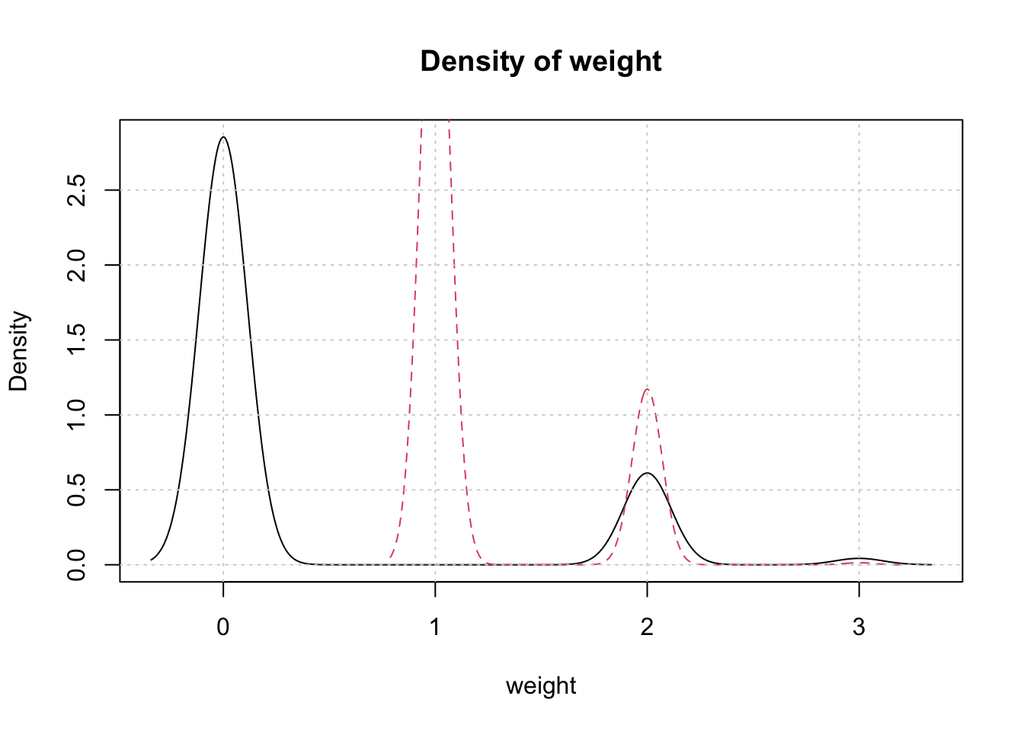

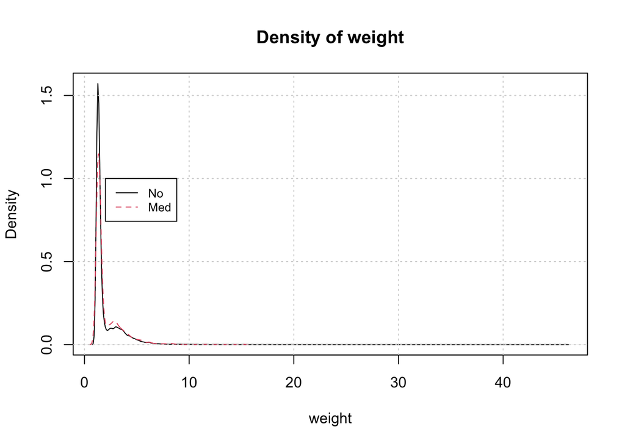

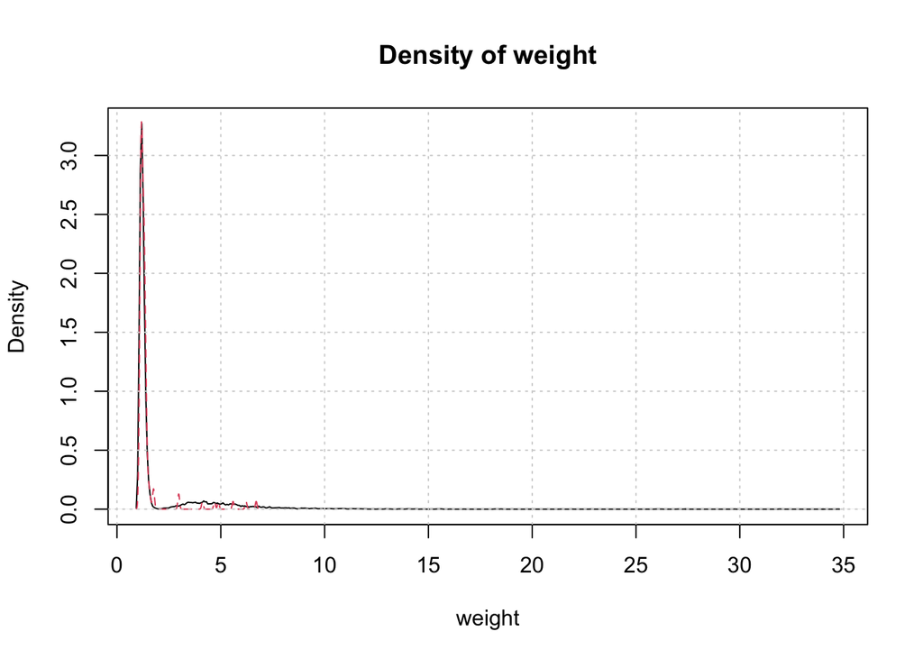

```r
#############sw: weight for binary treatment with propensity score, not ebal
for (i in seq(1:3)) {
  dataxw <- cweight_df[, c(12 + i, 16 + i)]
  head(dataxw)
  wgtdensityplot(dataxw)
}
```

###Block

```r
head(cweight_df)
```

```
##   x1 x2 x3 x4 x5 x6 x7 x8 x9 x10 x11 x12 a1 a2 a3 y A      sw1       sw2
## 1  2  2  1  1  3 46  0 16  0   0   1   9  0  1  0 0 2 1.600854 31.964865
## 2  2  2  1  1  4 40  0 13  0   0   1   9  1  0  0 1 1 2.967290  1.029561
## 3  2  1  0  1  2 49  0  1  0   0   0   6  1  0  0 1 1 4.529112  1.045715
## 4  2  2  1  1  1 51  0  8  0   0   0   6  1  0  0 1 1 2.824174  1.036541
## 5  2  1  0  2  1 37  0  7  0   0   0   3  1  0  0 1 1 2.599364  1.103120
## 6  5  1  1  2  8 46  1  7  0   0   2   8  0  1  0 1 2 1.164611 27.341014
##        sw3
## 1 1.004766
## 2 1.004093
## 3 1.003950
## 4 1.007800
## 5 1.010143
## 6 1.001858
```

```r
df.cbd<-cweight_df
table(df.cbd$x4)
```

```
##
##    1    2    3    4    5    6    7    8    9
##   32  152  460 1362 2480 3360 4375 2839  103
```

```r
df.cbd<-cweight_df
df.cbd[df.cbd$x4<=4,"block"]<-1
df.cbd[df.cbd$x4==5,"block"]<-2
df.cbd[df.cbd$x4==6,"block"]<-3
df.cbd[df.cbd$x4==7,"block"]<-4
df.cbd[df.cbd$x4==8 |df.cbd$x4==9,"block"]<-5
table(df.cbd$block)
```

```
##
##    1    2    3    4    5
## 2006 2480 3360 4375 2942
```

```r
table(df.cbd$block,df.cbd$x4)
```

```
##
##        1    2    3    4    5    6    7    8    9
##   1   32  152  460 1362    0    0    0    0    0
##   2    0    0    0    0 2480    0    0    0    0
##   3    0    0    0    0    0 3360    0    0    0
##   4    0    0    0    0    0    0 4375    0    0
##   5    0    0    0    0    0    0    0 2839  103
```

```r
table(df.cbd$block,df.cbd$A)
```

```
##
##        0    1    2    3
##   1 1366  448  181   11
##   2 1486  633  339   22
##   3 1979  780  558   43
##   4 2437  909  987   42
##   5 1695  504  717   26
```

```r
library(reshape2)
  dfmean <- data.frame()
  dfvar <- data.frame()
  #ti<-4
  for (ti in seq(1:4)) {
    for (bi in seq(1:5)) {
      df.block <- df.cbd[df.cbd$block == bi, ]
      df.men <- df.block[df.block$A == (ti - 1), "y"]
      temp <- mean(df.men)
      dfmean <- rbind(dfmean, temp)
      tempvar <- var(df.men)
      dfvar <- rbind(dfvar, tempvar)
    }
  }

  names(dfmean) <- c("mean")
  names(dfvar) <- c("var")
  mat.mea <- round(dfmean$mean, 3)
  mat.var <- round(dfvar$var, 3)
  mat.mean <- matrix(mat.mea, nrow = 5, ncol = 4)
  mat.var <- matrix(mat.var, nrow = 5, ncol = 4)
  mat.mvar <- cbind(mat.mean, mat.var)
  print(mat.mvar)
```

```
##       [,1]  [,2]  [,3]  [,4]  [,5]  [,6]  [,7]  [,8]
## [1,] 0.764 0.830 0.796 0.727 0.180 0.141 0.164 0.218
## [2,] 0.791 0.795 0.796 0.818 0.166 0.163 0.163 0.156
## [3,] 0.754 0.771 0.789 0.791 0.186 0.177 0.167 0.169
## [4,] 0.749 0.788 0.756 0.786 0.188 0.167 0.185 0.172
## [5,] 0.769 0.750 0.767 0.885 0.178 0.188 0.179 0.106
```

```r
  dat <- melt(t(as.matrix(mat.mean)))
  datvar <- melt(t(as.matrix(mat.var)))
  dat.mvar <- cbind(dat, datvar[, 3])
  print(dat.mvar)
```

```
##    Var1 Var2 value datvar[, 3]
## 1     1    1 0.764       0.180
## 2     2    1 0.830       0.141
## 3     3    1 0.796       0.164
## 4     4    1 0.727       0.218
## 5     1    2 0.791       0.166
## 6     2    2 0.795       0.163
## 7     3    2 0.796       0.163
## 8     4    2 0.818       0.156
## 9     1    3 0.754       0.186
## 10    2    3 0.771       0.177
## 11    3    3 0.789       0.167
## 12    4    3 0.791       0.169
## 13    1    4 0.749       0.188
## 14    2    4 0.788       0.167
## 15    3    4 0.756       0.185
## 16    4    4 0.786       0.172
## 17    1    5 0.769       0.178
## 18    2    5 0.750       0.188
## 19    3    5 0.767       0.179
## 20    4    5 0.885       0.106
```

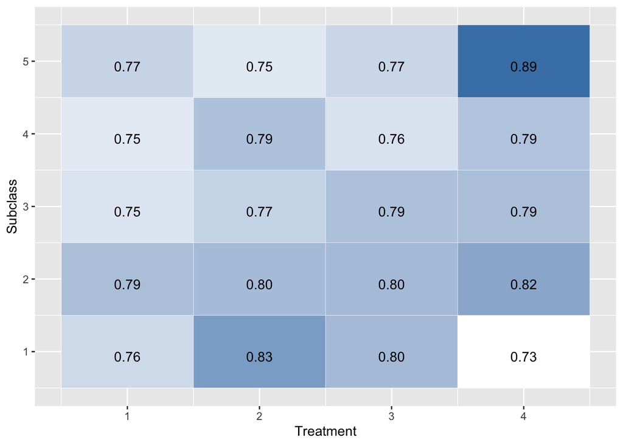

```
## [1] 0
```

```r
  names(dat.mvar) <- c("Var1", "Var2", "mean", "Var")

    blockplot(dat)
```

```r
   pdf(file ="~/Downloads/Rpkg/cvmfd/man_ffd/blockplot.pdf", width = 5, height = 4.8)
  blockplot(dat)
```

```
## [1] 0
```

```r
   dev.off()
```

```r
#mat.mean<-mat.mvar[,c(1:4)]
```

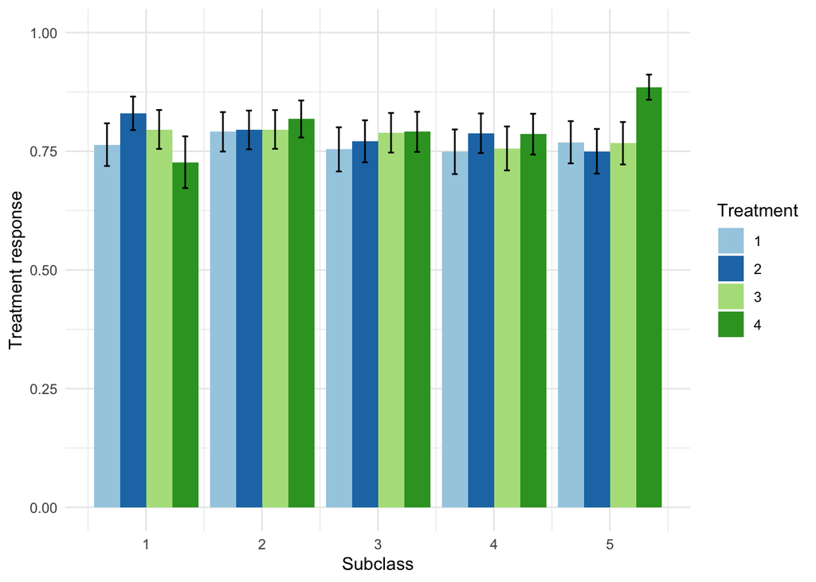

```r
{
p <- ggplot(dat.mvar, aes(x=Var2, y=mean, fill=as.factor(Var1))) +
   geom_bar(stat="identity", position=position_dodge()) +
  geom_errorbar(aes(ymin=mean-(Var/4), ymax=mean+(Var)/4), width=.2,
                 position=position_dodge(.9)) + scale_fill_brewer(palette="Paired") + theme_minimal()+
  ylim(0, 1.0)+
  xlab("Subclass")+ylab("Treatment response")+ labs(fill = "Treatment")
print(p)#;Stratum

#save(p)
ggsave(filename="response.pdf", plot=p, width = 5, height = 4.8,
 units = "in") # other options c("in", "cm", "mm"),
}
```

```r
print(dat.mvar)
```

```
##    Var1 Var2  mean   Var
## 1     1    1 0.764 0.180
## 2     2    1 0.830 0.141
## 3     3    1 0.796 0.164
## 4     4    1 0.727 0.218
## 5     1    2 0.791 0.166
## 6     2    2 0.795 0.163
## 7     3    2 0.796 0.163
## 8     4    2 0.818 0.156
## 9     1    3 0.754 0.186
## 10    2    3 0.771 0.177
## 11    3    3 0.789 0.167
## 12    4    3 0.791 0.169
## 13    1    4 0.749 0.188
## 14    2    4 0.788 0.167
## 15    3    4 0.756 0.185
## 16    4    4 0.786 0.172
## 17    1    5 0.769 0.178
## 18    2    5 0.750 0.188
## 19    3    5 0.767 0.179
## 20    4    5 0.885 0.106
```

```r
   print("###############LR with dual responses################")
```

```
## [1] "###############LR with dual responses################"
```

```r
  df.lr<-dat
  for (ind in seq(1:20)) {
    if(df.lr[ind,"Var1"]==1){
    df.lr[ind,"x1"]<--1
    df.lr[ind,"x2"]<--1
  }else if(df.lr[ind,"Var1"]==2){
    df.lr[ind,"x1"]<--1
    df.lr[ind,"x2"]<-1
  }else if(df.lr[ind,"Var1"]==3){
    df.lr[ind,"x1"]<-1
    df.lr[ind,"x2"]<--1
  }else{
    df.lr[ind,"x1"]<-1
    df.lr[ind,"x2"]<-1
  }
}
  ##LR
    lrq.mat<-lm(value~x1+x2+  I(x1^2)+I(x2^2)+x1*x2, data = df.lr)
  print(summary(lrq.mat))
```

```
##
## Call:
## lm(formula = value ~ x1 + x2 + I(x1^2) + I(x2^2) + x1 * x2, data = df.lr)
##
## Residuals:
##     Min      1Q  Median      3Q     Max
## -0.0744 -0.0155 -0.0001  0.0152  0.0836
##
## Coefficients: (2 not defined because of singularities)
##              Estimate Std. Error t value Pr(>|t|)
## (Intercept)  0.783600   0.007723 101.459   <2e-16 ***
## x1           0.007500   0.007723   0.971    0.346
## x2           0.010500   0.007723   1.360    0.193
## I(x1^2)            NA         NA      NA       NA
## I(x2^2)            NA         NA      NA       NA
## x1:x2       -0.000200   0.007723  -0.026    0.980
## ---
## Signif. codes:  0 '***' 0.001 '**' 0.01 '*' 0.05 '.' 0.1 ' ' 1
##
## Residual standard error: 0.03454 on 16 degrees of freedom
## Multiple R-squared:  0.1486, Adjusted R-squared:  -0.01107
## F-statistic: 0.9307 on 3 and 16 DF,  p-value: 0.4487
```

```r
  #xtable(aov(lrq.mat))
  res.aov <- aov(value~x1+x2+x1*x2, data = df.lr)
   print(summary(res.aov))
```

```
##             Df   Sum Sq   Mean Sq F value Pr(>F)
## x1           1 0.001125 0.0011250   0.943  0.346
## x2           1 0.002205 0.0022050   1.848  0.193
## x1:x2        1 0.000001 0.0000008   0.001  0.980
## Residuals   16 0.019088 0.0011930
```

```r
print( xtable(aov(res.aov),digits = 4))
```

```
## % latex table generated in R 4.0.2 by xtable 1.8-4 package
## % Mon May 24 09:18:32 2021
## \begin{table}[ht]
## \centering
## \begin{tabular}{lrrrrr}
##   \hline
##  & Df & Sum Sq & Mean Sq & F value & Pr($>$F) \\
##   \hline
## x1 & 1.0000 & 0.0011 & 0.0011 & 0.9430 & 0.3460 \\
##   x2 & 1.0000 & 0.0022 & 0.0022 & 1.8483 & 0.1928 \\
##   x1:x2 & 1.0000 & 0.0000 & 0.0000 & 0.0007 & 0.9797 \\
##   Residuals & 16.0000 & 0.0191 & 0.0012 &  &  \\
##    \hline
## \end{tabular}
## \end{table}
```

```r
       print("################above: x1+x2+x1*x2################")
```

```
## [1] "################above: x1+x2+x1*x2################"
```

```r
   lrq.mat<-lm(value~x1+x2+  I(x1^2)+I(x2^2)+x1*x2+Var2+x1*Var2+x2*Var2, data = df.lr)
  print(summary(lrq.mat))
```

```
##
## Call:
## lm(formula = value ~ x1 + x2 + I(x1^2) + I(x2^2) + x1 * x2 +
##     Var2 + x1 * Var2 + x2 * Var2, data = df.lr)
##
## Residuals:
##       Min        1Q    Median        3Q       Max
## -0.043450 -0.022019  0.002075  0.019106  0.052650
##
## Coefficients: (2 not defined because of singularities)
##              Estimate Std. Error t value Pr(>|t|)
## (Intercept)  0.784575   0.017118  45.832 9.24e-16 ***
## x1          -0.021375   0.017118  -1.249   0.2338
## x2          -0.008025   0.017118  -0.469   0.6470
## I(x1^2)            NA         NA      NA       NA
## I(x2^2)            NA         NA      NA       NA
## Var2        -0.000325   0.005161  -0.063   0.9508
## x1:x2       -0.000200   0.007299  -0.027   0.9786
## x1:Var2      0.009625   0.005161   1.865   0.0849 .
## x2:Var2      0.006175   0.005161   1.196   0.2529
## ---
## Signif. codes:  0 '***' 0.001 '**' 0.01 '*' 0.05 '.' 0.1 ' ' 1
##
## Residual standard error: 0.03264 on 13 degrees of freedom
## Multiple R-squared:  0.3821, Adjusted R-squared:  0.09689
## F-statistic:  1.34 on 6 and 13 DF,  p-value: 0.3081
```

```r
   res.aov <- aov(value~x1+x2+x1*x2+x1*Var2+x2*Var2, data = df.lr)
   print(summary(res.aov))
```

```
##             Df   Sum Sq  Mean Sq F value Pr(>F)
## x1           1 0.001125 0.001125   1.056 0.3229
## x2           1 0.002205 0.002205   2.069 0.1739
## Var2         1 0.000004 0.000004   0.004 0.9508
## x1:x2        1 0.000001 0.000001   0.001 0.9786
## x1:Var2      1 0.003706 0.003706   3.477 0.0849 .
## x2:Var2      1 0.001525 0.001525   1.431 0.2529
## Residuals   13 0.013853 0.001066
## ---
## Signif. codes:  0 '***' 0.001 '**' 0.01 '*' 0.05 '.' 0.1 ' ' 1
```

```r
print( xtable(aov(res.aov),digits = 4))
```

```
## % latex table generated in R 4.0.2 by xtable 1.8-4 package
## % Mon May 24 09:18:32 2021
## \begin{table}[ht]
## \centering
## \begin{tabular}{lrrrrr}
##   \hline
##  & Df & Sum Sq & Mean Sq & F value & Pr($>$F) \\
##   \hline
## x1 & 1.0000 & 0.0011 & 0.0011 & 1.0557 & 0.3229 \\
##   x2 & 1.0000 & 0.0022 & 0.0022 & 2.0692 & 0.1739 \\
##   Var2 & 1.0000 & 0.0000 & 0.0000 & 0.0040 & 0.9508 \\
##   x1:x2 & 1.0000 & 0.0000 & 0.0000 & 0.0008 & 0.9786 \\
##   x1:Var2 & 1.0000 & 0.0037 & 0.0037 & 3.4775 & 0.0849 \\
##   x2:Var2 & 1.0000 & 0.0015 & 0.0015 & 1.4313 & 0.2529 \\
##   Residuals & 13.0000 & 0.0139 & 0.0011 &  &  \\
##    \hline
## \end{tabular}
## \end{table}
```

```r
#####
#names(ggplot.df)<-c("group","rep1","rep2","rep1se","rep2se")
 # line.df<-ggplot.df[,1:3]
#  line.dfrep<-ggplot.df[,2]-ggplot.df[,3]
   print(pdf(file ="~/Downloads/Rpkg/cvmfd/man_ffd/str.pdf", width = 5, height = 4.8))
```

```r
# respsurfaceplot5s(mat.mean)
  # xlab = c("Subclass") # Stratum xlab = c("Blocks")#, ylab = expression(V(A))
   #        ylab=c("Objective V(A,Y)")
# pdf(file ="~/Downloads/Rpkg/cvmfd/man_ffd/str.pdf", width = 5, height = 4.8)
# dev.off()
  respsurfaceplot5s(mat.mean)
```

```
## [1] 0.8045
```

```r
head(dat.mvar)
```

```
##   Var1 Var2  mean   Var
## 1    1    1 0.764 0.180
## 2    2    1 0.830 0.141
## 3    3    1 0.796 0.164
## 4    4    1 0.727 0.218
## 5    1    2 0.791 0.166
## 6    2    2 0.795 0.163
```

```r
dat.mvar$Cell<-dat.mvar$Var1+(dat.mvar$Var2-1)*4

    resp.df<-dat.mvar[,c(5,3,4)]
```

## Solution for each blocks

```r
head(dat.mvar)
```

```
##   Var1 Var2  mean   Var Cell
## 1    1    1 0.764 0.180    1
## 2    2    1 0.830 0.141    2
## 3    3    1 0.796 0.164    3
## 4    4    1 0.727 0.218    4
## 5    1    2 0.791 0.166    5
## 6    2    2 0.795 0.163    6
```

```r
#opt.bmse<-optcretria(dat.mvar,"min")
opt.bmse<-optcretria5s(dat.mvar,"max")
head(opt.bmse)
```

```
##    Var1 Var2  mean   Var Cell  optv block treatment
## 2     2    1 0.830 0.141    2 0.830     1         2
## 8     4    2 0.818 0.156    8 0.818     2         0
## 12    4    3 0.791 0.169   12 0.791     3         0
## 14    2    4 0.788 0.167   14 0.788     4         2
## 20    4    5 0.885 0.106   20 0.885     5         0
```

```r
xtable(opt.bmse)
```

```
## % latex table generated in R 4.0.2 by xtable 1.8-4 package
## % Mon May 24 09:18:32 2021
## \begin{table}[ht]
## \centering
## \begin{tabular}{rrrrrrrrr}
##   \hline
##  & Var1 & Var2 & mean & Var & Cell & optv & block & treatment \\
##   \hline
## 2 &   2 &   1 & 0.83 & 0.14 & 2.00 & 0.83 & 1.00 & 2.00 \\
##   8 &   4 &   2 & 0.82 & 0.16 & 8.00 & 0.82 & 2.00 & 0.00 \\
##   12 &   4 &   3 & 0.79 & 0.17 & 12.00 & 0.79 & 3.00 & 0.00 \\
##   14 &   2 &   4 & 0.79 & 0.17 & 14.00 & 0.79 & 4.00 & 2.00 \\
##   20 &   4 &   5 & 0.89 & 0.11 & 20.00 & 0.89 & 5.00 & 0.00 \\
##    \hline
## \end{tabular}
## \end{table}
```

ebalnce use low corratina variables

```r
head(df.cbd)
```

```
##   x1 x2 x3 x4 x5 x6 x7 x8 x9 x10 x11 x12 a1 a2 a3 y A      sw1       sw2
## 1  2  2  1  1  3 46  0 16  0   0   1   9  0  1  0 0 2 1.600854 31.964865
## 2  2  2  1  1  4 40  0 13  0   0   1   9  1  0  0 1 1 2.967290  1.029561
## 3  2  1  0  1  2 49  0  1  0   0   0   6  1  0  0 1 1 4.529112  1.045715
## 4  2  2  1  1  1 51  0  8  0   0   0   6  1  0  0 1 1 2.824174  1.036541
## 5  2  1  0  2  1 37  0  7  0   0   0   3  1  0  0 1 1 2.599364  1.103120
## 6  5  1  1  2  8 46  1  7  0   0   2   8  0  1  0 1 2 1.164611 27.341014
##        sw3 block
## 1 1.004766     1
## 2 1.004093     1
## 3 1.003950     1
## 4 1.007800     1
## 5 1.010143     1
## 6 1.001858     1
```

```r
 cor(df.cbd[, c(1:12)])
```

```
##               x1           x2           x3           x4           x5
## x1   1.000000000 -0.099537568  0.039084989 -0.116142785  0.041214738
## x2  -0.099537568  1.000000000 -0.051769572  0.130709484 -0.041891583
## x3   0.039084989 -0.051769572  1.000000000  0.025030849  0.052033934
## x4  -0.116142785  0.130709484  0.025030849  1.000000000  0.054994815
## x5   0.041214738 -0.041891583  0.052033934  0.054994815  1.000000000
## x6   0.003397749 -0.005834172  0.021810587 -0.000596154  0.294953271
## x7  -0.080181058  0.005267195 -0.063408032 -0.029522755  0.175145005
## x8   0.064582248  0.021855260  0.062669036 -0.019271421  0.440075669
## x9   0.102217590  0.052039432  0.012599520  0.021009284 -0.009862708
## x10  0.254541985 -0.021384579  0.036300811 -0.131738868 -0.018365065
## x11  0.615290036 -0.049205341  0.028722251 -0.098202840  0.073002139
## x12  0.094009660  0.043866313  0.002086271  0.125295338  0.194212134
##               x6           x7          x8           x9         x10         x11
## x1   0.003397749 -0.080181058  0.06458225  0.102217590  0.25454199  0.61529004
## x2  -0.005834172  0.005267195  0.02185526  0.052039432 -0.02138458 -0.04920534
## x3   0.021810587 -0.063408032  0.06266904  0.012599520  0.03630081  0.02872225
## x4  -0.000596154 -0.029522755 -0.01927142  0.021009284 -0.13173887 -0.09820284
## x5   0.294953271  0.175145005  0.44007567 -0.009862708 -0.01836506  0.07300214
## x6   1.000000000  0.036072803  0.24717586  0.028875292  0.02034337  0.05744712
## x7   0.036072803  1.000000000  0.31608749 -0.031856313 -0.04375833 -0.07878622
## x8   0.247175860  0.316087495  1.00000000  0.075486755  0.03122233  0.07825260
## x9   0.028875292 -0.031856313  0.07548676  1.000000000  0.10684209  0.10540665
## x10  0.020343367 -0.043758326  0.03122233  0.106842090  1.00000000  0.24113162
## x11  0.057447125 -0.078786216  0.07825260  0.105406647  0.24113162  1.00000000
## x12  0.148167903  0.057532227  0.22976307  0.106131541  0.06317929  0.09817601
##             x12
## x1  0.094009660
## x2  0.043866313
## x3  0.002086271
## x4  0.125295338
## x5  0.194212134
## x6  0.148167903
## x7  0.057532227
## x8  0.229763073
## x9  0.106131541
## x10 0.063179287
## x11 0.098176015
## x12 1.000000000
```

```r
  cor(df.cbd[, c(1:3,7,12)])
```

```
##              x1           x2           x3           x7         x12
## x1   1.00000000 -0.099537568  0.039084989 -0.080181058 0.094009660
## x2  -0.09953757  1.000000000 -0.051769572  0.005267195 0.043866313
## x3   0.03908499 -0.051769572  1.000000000 -0.063408032 0.002086271
## x7  -0.08018106  0.005267195 -0.063408032  1.000000000 0.057532227
## x12  0.09400966  0.043866313  0.002086271  0.057532227 1.000000000
```

```r
dist.out<-data.frame(dist.out)
names(dist.out)<-c("block","treatment","dist")
#temp<-dat.mvar[c(13:17),c(1:3)]
temp<-dat.mvar[c(4,8,12,16,20),c(1:3)]
names(temp)<-c("treatment","block","dist")
temp$dist<-0
temp<-temp[,c(2,1,3)]
dist.outdf<-rbind(dist.out,temp)
dist.outdf$Cell<-(dist.outdf$block-1)*4+dist.outdf$treatment
dist.outdf<-dist.outdf[order(dist.outdf$Cell),]
dist.outdf
```

```
##     block treatment  dist Cell
## 1       1         1 5.677    1
## 2       1         2 3.668    2
## 3       1         3 4.068    3
## 41      1         4 0.000    4
## 4       2         1 1.424    5
## 5       2         2 0.760    6
## 6       2         3 0.803    7
## 81      2         4 0.000    8
## 7       3         1 0.646    9
## 8       3         2 0.451   10
## 9       3         3 0.568   11
## 121     3         4 0.000   12
## 10      4         1 0.541   13
## 11      4         2 0.395   14
## 12      4         3 0.326   15
## 16      4         4 0.000   16
## 13      5         1 0.413   17
## 14      5         2 0.081   18
## 15      5         3 0.211   19
## 20      5         4 0.000   20
```

```r
kld.neg<-data.frame()
kld.neg<-cbind(kldconv.dfc$bi,kldconv.dfc$ti,-(kldconv.dfc$kld))
kld.neg<-data.frame(kld.neg)
names(kld.neg)<-c("block","treatment","negkld")
#temp<-dat.mvar[c(13:16),c(1:3)]
#names(temp)<-c("block","treatment","negkld")
temp<-dat.mvar[c(4,8,12,16,20),c(1:3)]
names(temp)<-c("treatment","block","negkld")
temp$dist<-0
temp<-temp[,c(2,1,3)]
temp$negkld<-0
kld.neg<-rbind(kld.neg,temp)
kld.neg$Cell<-(kld.neg$block-1)*4+kld.neg$treatment
kld.neg<-kld.neg[order(kld.neg$Cell),]
kld.neg
```

```
##     block treatment negkld Cell
## 1       1         1 -0.531    1
## 2       1         2 -0.497    2
## 3       1         3 -0.367    3
## 41      1         4  0.000    4
## 4       2         1 -0.247    5
## 5       2         2 -0.271    6
## 6       2         3 -0.160    7
## 81      2         4  0.000    8
## 7       3         1 -0.113    9
## 8       3         2 -0.043   10
## 9       3         3 -0.057   11
## 121     3         4  0.000   12
## 10      4         1 -0.145   13
## 11      4         2 -0.099   14
## 12      4         3 -0.125   15
## 16      4         4  0.000   16
## 13      5         1 -0.076   17
## 14      5         2 -0.046   18
## 15      5         3 -0.079   19
## 20      5         4  0.000   20
```

```r
resp.df
```

```
##    Cell  mean   Var
## 1     1 0.764 0.180
## 2     2 0.830 0.141
## 3     3 0.796 0.164
## 4     4 0.727 0.218
## 5     5 0.791 0.166
## 6     6 0.795 0.163
## 7     7 0.796 0.163
## 8     8 0.818 0.156
## 9     9 0.754 0.186
## 10   10 0.771 0.177
## 11   11 0.789 0.167
## 12   12 0.791 0.169
## 13   13 0.749 0.188
## 14   14 0.788 0.167
## 15   15 0.756 0.185
## 16   16 0.786 0.172
## 17   17 0.769 0.178
## 18   18 0.750 0.188
## 19   19 0.767 0.179
## 20   20 0.885 0.106
```

```r
#0:2, vs. 3
df.mean
```

```
##    Cell      mean        Var
## 1     1 0.7546552 0.03984626
## 2     2 0.8241549 0.09600699
## 3     3 0.8699816 0.20979038
## 4     5 0.7995232 0.08827104
## 5     6 0.8300134 0.21360670
## 6     7 0.8666948 0.31210976
## 7     9 0.7676663 0.21105619
## 8    10 0.8141156 0.46340256
## 9    11 0.8532374 0.64410640
## 10   13 0.7643454 0.19998502
## 11   14 0.8139642 0.40467284
## 12   15 0.7770648 0.45666527
## 13   17 0.7791146 0.08493500
## 14   18 0.7869531 0.27435685
## 15   19 0.8049494 0.19976134
```

```r
df.wgt<-rbind(df.mean,resp.df[c(4,8,12,16,20),])

df.wgt<-round(df.wgt,3)
df.wgt<-df.wgt[order(df.wgt$Cell),]
df.wgt
```

```
##     Cell  mean   Var
## 1      1 0.755 0.040
## 2      2 0.824 0.096
## 3      3 0.870 0.210
## 41     4 0.727 0.218
## 4      5 0.800 0.088
## 5      6 0.830 0.214
## 6      7 0.867 0.312
## 81     8 0.818 0.156
## 7      9 0.768 0.211
## 8     10 0.814 0.463
## 9     11 0.853 0.644
## 121   12 0.791 0.169
## 10    13 0.764 0.200
## 11    14 0.814 0.405
## 12    15 0.777 0.457
## 16    16 0.786 0.172
## 13    17 0.779 0.085
## 14    18 0.787 0.274
## 15    19 0.805 0.200
## 20    20 0.885 0.106
```

```r
dat.mvar<-df.wgt
#Va1:Treat; Var2: Blcok
head(dat.mvar)
```

```
##    Cell  mean   Var
## 1     1 0.755 0.040
## 2     2 0.824 0.096
## 3     3 0.870 0.210
## 41    4 0.727 0.218
## 4     5 0.800 0.088
## 5     6 0.830 0.214
```

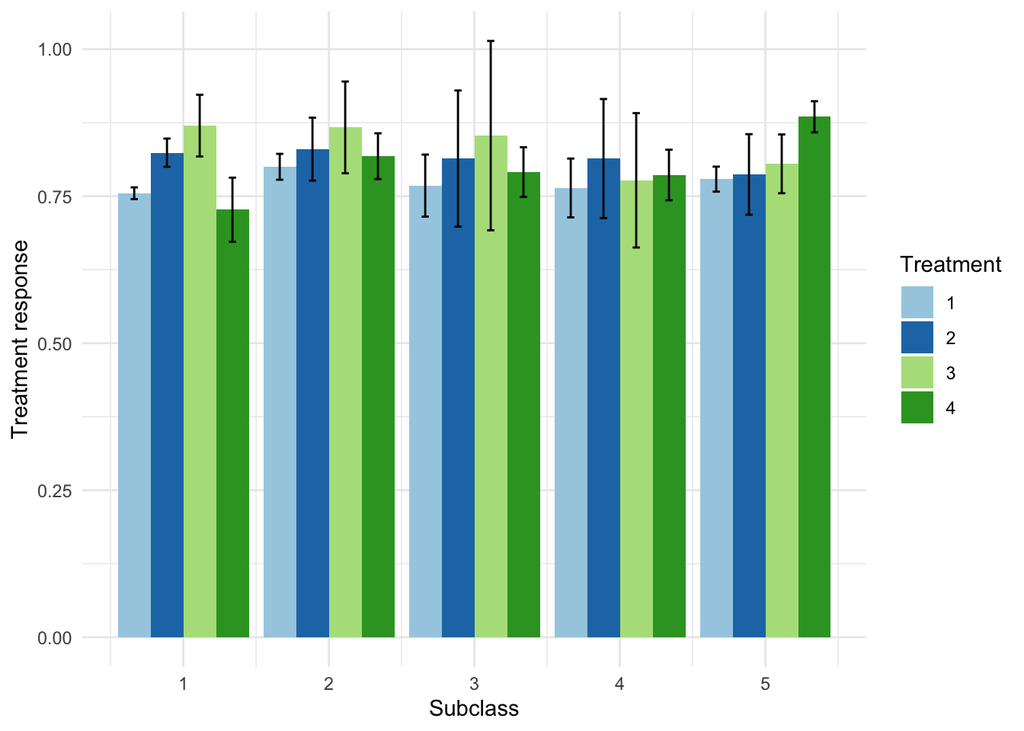

```r
dat.mvar2<-dat.mvar
dat.mvar2$Var1<-rep(1:4,5)
dat.mvar2$Var2<-rep(1:5,each=4)
#opt.bmse<-optcretria(dat.mvar,"min")
#opt.bmse<-optcretria(dat.mvar,"max")
#head(opt.bmse)
#xtable(opt.bmse)
#opt.cmr<-mean(opt.bmse$mean)
#opt.cmr
{
p <- ggplot(dat.mvar2, aes(x=Var2, y=mean, fill=as.factor(Var1))) +
   geom_bar(stat="identity", position=position_dodge()) +
  geom_errorbar(aes(ymin=mean-(Var)/4, ymax=mean+(Var)/4), width=.2,
                 position=position_dodge(.9)) + scale_fill_brewer(palette="Paired") + theme_minimal()+
  xlab("Subclass")+ylab("Treatment response")+ labs(fill = "Treatment")
print(p)#;Stratum

#save(p)
ggsave(filename="responsewt.pdf", plot=p, width = 5, height = 4.8,
 units = "in") # other options c("in", "cm", "mm"),
}
```

```r
 print(dat.mvar2)
```

```
##     Cell  mean   Var Var1 Var2
## 1      1 0.755 0.040    1    1
## 2      2 0.824 0.096    2    1
## 3      3 0.870 0.210    3    1
## 41     4 0.727 0.218    4    1
## 4      5 0.800 0.088    1    2
## 5      6 0.830 0.214    2    2
## 6      7 0.867 0.312    3    2
## 81     8 0.818 0.156    4    2
## 7      9 0.768 0.211    1    3
## 8     10 0.814 0.463    2    3
## 9     11 0.853 0.644    3    3
## 121   12 0.791 0.169    4    3
## 10    13 0.764 0.200    1    4
## 11    14 0.814 0.405    2    4
## 12    15 0.777 0.457    3    4
## 16    16 0.786 0.172    4    4
## 13    17 0.779 0.085    1    5
## 14    18 0.787 0.274    2    5
## 15    19 0.805 0.200    3    5
## 20    20 0.885 0.106    4    5
```

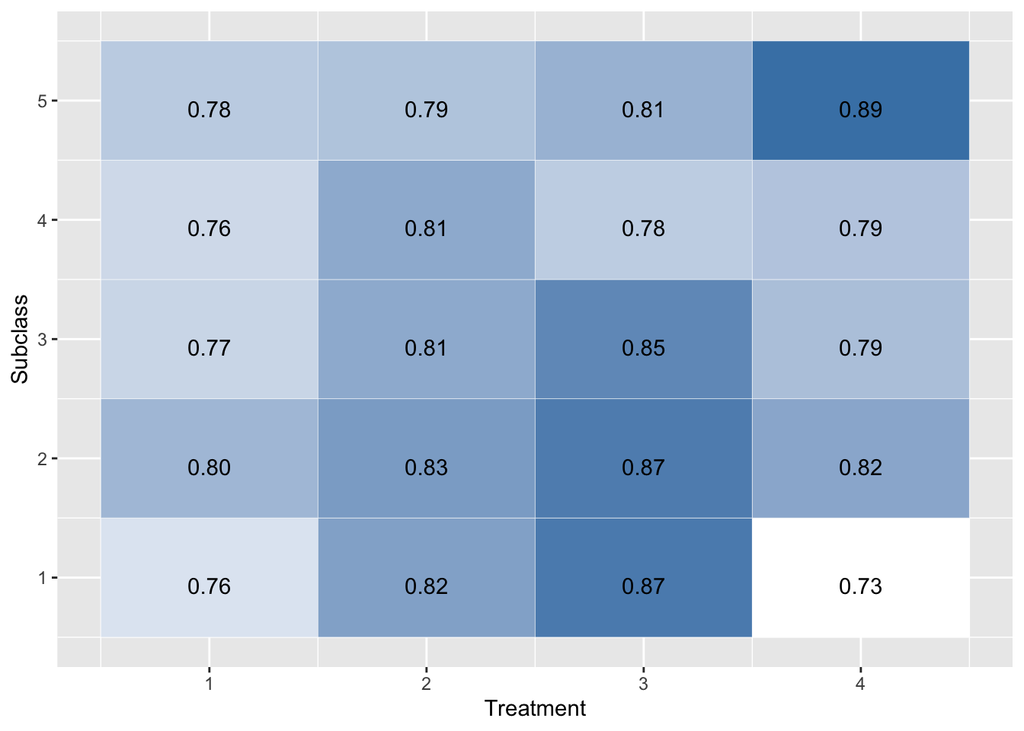

```
## [1] 0
```

```r
   mat.meanwt <- matrix(dat.mvar2$mean, nrow = 4, ncol = 5)
 datwt <- melt((as.matrix(mat.meanwt)))
#  datvar <- melt(t(as.matrix(mat.var)))
#  dat.mvar <- cbind(dat, datvar[, 3])
 # print(dat.mvar)
 # names(dat.mvar) <- c("Var1", "Var2", "mean", "Var")

    blockplot(datwt)
```

```r
    {
   pdf(file ="~/Downloads/Rpkg/cvmfd/man_ffd/blockplotwt.pdf", width = 5, height = 4.8)
  blockplot(datwt)
   dev.off()
}
```

```r
mat.assign<-matrixassign5s(mat.mean)
opt.bmse<-matrixassign5s(mat.mean)
```

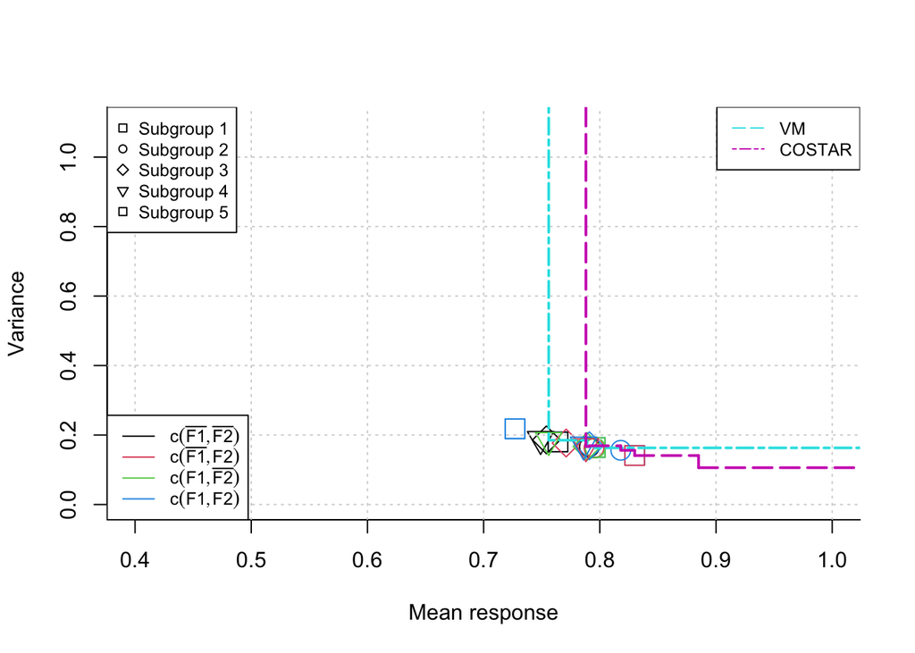

```
## NULL
##     mean   Var
## 2  0.830 0.141
## 8  0.818 0.156
## 12 0.791 0.169
## 14 0.788 0.167
## 20 0.885 0.106
```

```
## [1] 0
```

```r
#df.sol
paretoplotpositive5s(resp.df,opt.bmse)
```

```r
opt.bmse[,c(2:3)]
```

```
##   block treatment
## 1     1         2
## 2     2         4
## 3     3         4
## 4     4         2
## 5     5         4
```

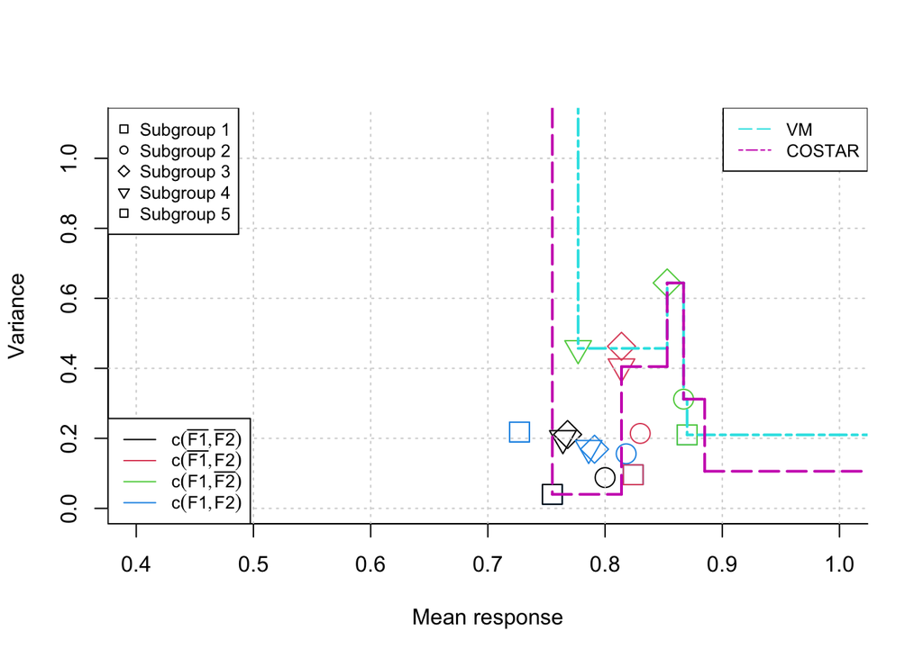

```
## NULL
##     mean   Var
## 1  0.755 0.040
## 6  0.867 0.312
## 9  0.853 0.644
## 11 0.814 0.405
## 20 0.885 0.106
```

```
## [1] 0
```

```r
#####
mat.mean<-matrix(df.wgt$mean,nrow = 5, ncol = 4)
mat.assign<-matrixassign5s((mat.mean))
df.sol<-mat.assign
#paretoplot(df.wgt,df.sol)
df.wgt<-data.frame(df.wgt)
#opt.bmse2<-df.wgt[df.wgt$Cell==df.sol$Cell,]
opt.bmse2<-df.wgt[c(1,7,11,14,20),]
paretoplotpositive5s(df.wgt,(opt.bmse2))
```

```r
df.out<-df.sol[,c(2,4,4,3,1)]
library(xtable)
xtable(df.out)
```

```
## % latex table generated in R 4.0.2 by xtable 1.8-4 package
## % Mon May 24 09:18:38 2021
## \begin{table}[ht]
## \centering
## \begin{tabular}{rrrrrr}
##   \hline
##  & block & Cell & Cell.1 & treatment & objv \\
##   \hline
## 1 &   1 & 3.00 & 3.00 &   3 & 0.85 \\
##   2 &   2 & 6.00 & 6.00 &   2 & 0.87 \\
##   3 &   3 & 9.00 & 9.00 &   1 & 0.87 \\
##   4 &   4 & 15.00 & 15.00 &   3 & 0.81 \\
##   5 &   5 & 20.00 & 20.00 &   4 & 0.89 \\
##    \hline
## \end{tabular}
## \end{table}
```

###KLD as secondary responses

```r
head(kld.neg)
```

```
##    block treatment negkld Cell
## 1      1         1 -0.531    1
## 2      1         2 -0.497    2
## 3      1         3 -0.367    3
## 41     1         4  0.000    4
## 4      2         1 -0.247    5
## 5      2         2 -0.271    6
```

```r
reps.kld<-cbind(resp.df,kld.neg$negkld)
paretodf<-reps.kld[,c(1,2,4)]
head(paretodf)
```

```
##   Cell  mean kld.neg$negkld
## 1    1 0.764         -0.531
## 2    2 0.830         -0.497
## 3    3 0.796         -0.367
## 4    4 0.727          0.000
## 5    5 0.791         -0.247
## 6    6 0.795         -0.271
```

```r
#names(paretodf)
#kldopt.bmse<-
  #matrixassign(kld.mat)[c(1:4),]
pdf(file ="~/Downloads/Rpkg/cvmfd/man_ffd/paretowt.pdf", width = 5, height = 4.8)
paretoplot(paretodf,opt.bmse)
```

```
## NULL
##     mean    Var
## 2  0.830 -0.497
## 8  0.818  0.000
## 12 0.791  0.000
## 14 0.788 -0.099
## 20 0.885  0.000
```

```
## [1] 0
```

```r
  dev.off()
```

```r
kld.mat<-matrix( paretodf[,3],nrow = 4)


df.wgt
```

```
##     Cell  mean   Var
## 1      1 0.755 0.040
## 2      2 0.824 0.096
## 3      3 0.870 0.210
## 41     4 0.727 0.218
## 4      5 0.800 0.088
## 5      6 0.830 0.214
## 6      7 0.867 0.312
## 81     8 0.818 0.156
## 7      9 0.768 0.211
## 8     10 0.814 0.463
## 9     11 0.853 0.644
## 121   12 0.791 0.169
## 10    13 0.764 0.200
## 11    14 0.814 0.405
## 12    15 0.777 0.457
## 16    16 0.786 0.172
## 13    17 0.779 0.085
## 14    18 0.787 0.274
## 15    19 0.805 0.200
## 20    20 0.885 0.106
```

```r
names(paretodf)<-c("Cell","mean","negkld")

paretodf$objv<-round(paretodf$mean+0.001*paretodf[,3],2)
paretodf
```

```
##    Cell  mean negkld objv
## 1     1 0.764 -0.531 0.76
## 2     2 0.830 -0.497 0.83
## 3     3 0.796 -0.367 0.80
## 4     4 0.727  0.000 0.73
## 5     5 0.791 -0.247 0.79
## 6     6 0.795 -0.271 0.79
## 7     7 0.796 -0.160 0.80
## 8     8 0.818  0.000 0.82
## 9     9 0.754 -0.113 0.75
## 10   10 0.771 -0.043 0.77
## 11   11 0.789 -0.057 0.79
## 12   12 0.791  0.000 0.79
## 13   13 0.749 -0.145 0.75
## 14   14 0.788 -0.099 0.79
## 15   15 0.756 -0.125 0.76
## 16   16 0.786  0.000 0.79
## 17   17 0.769 -0.076 0.77
## 18   18 0.750 -0.046 0.75
## 19   19 0.767 -0.079 0.77
## 20   20 0.885  0.000 0.88
```

```r
df.vmax<-data.frame()
mat.mean<-matrix(df.wgt$mean,nrow = 5, ncol = 4)
for(bi in seq(1:4)){
  ggplot.df<-data.frame(mat.mean[bi,])
  names(ggplot.df)<-c("mean")
opt.vmax<-ggplot.df[ggplot.df$mean==max(ggplot.df$mean),]
opt.vmax$cretria<-"max"
opt.vmax$optv<-max(ggplot.df$mean)
df.vmax<-rbind(df.vmax,opt.vmax$optv)
}
df.vmax
```

```
##   X0.853
## 1  0.853
## 2  0.867
## 3  0.870
## 4  0.814
```

```r
head(mat.mean)
```

```
##       [,1]  [,2]  [,3]  [,4]
## [1,] 0.755 0.830 0.853 0.786
## [2,] 0.824 0.867 0.791 0.779
## [3,] 0.870 0.818 0.764 0.787
## [4,] 0.727 0.768 0.814 0.805
## [5,] 0.800 0.814 0.777 0.885
```

```r
# dev.off()
# respsurfaceplot5s(mat.mean)
mat.mean.wt<-matrix(df.wgt$mean,nrow=4)
mat.mean.w<-t(mat.mean.wt)
#respsurfaceplot5s(mat.mean.w)
print(pdf(file ="~/Downloads/Rpkg/cvmfd/man_ffd/strwt.pdf", width = 5, height = 4.8))
```

```r
#pdf(file ="~/Downloads/Rpkg/cvmfd/man_ffd/strwt.pdf", width = 5, height = 4.8)
 #dev.off()
 respsurfaceplot5s(mat.mean.w)
```

```
## [1] 0.8045
```

```r
#df.wgt
datvar<-melt(t(as.matrix(mat.mean.w)))
dat<-datvar
  df.lr<-dat
  for (ind in seq(1:20)) {
    if(df.lr[ind,"Var1"]==1){
    df.lr[ind,"x1"]<--1
    df.lr[ind,"x2"]<--1
  }else if(df.lr[ind,"Var1"]==2){
    df.lr[ind,"x1"]<--1
    df.lr[ind,"x2"]<-1
  }else if(df.lr[ind,"Var1"]==3){
    df.lr[ind,"x1"]<-1
    df.lr[ind,"x2"]<--1
  }else{
    df.lr[ind,"x1"]<-1
    df.lr[ind,"x2"]<-1
  }
}
  ##LR
    lrq.mat<-lm(value~x1+x2+  I(x1^2)+I(x2^2)+x1*x2, data = df.lr)
  print(summary(lrq.mat))
```

```
##
## Call:
## lm(formula = value ~ x1 + x2 + I(x1^2) + I(x2^2) + x1 * x2, data = df.lr)
##
## Residuals:
##     Min      1Q  Median      3Q     Max
## -0.0744 -0.0161  0.0002  0.0171  0.0836
##
## Coefficients: (2 not defined because of singularities)
##             Estimate Std. Error t value Pr(>|t|)
## (Intercept)  0.80570    0.00834  96.602   <2e-16 ***
## x1           0.01220    0.00834   1.463   0.1629
## x2           0.00190    0.00834   0.228   0.8227
## I(x1^2)           NA         NA      NA       NA
## I(x2^2)           NA         NA      NA       NA
## x1:x2       -0.01840    0.00834  -2.206   0.0423 *
## ---
## Signif. codes:  0 '***' 0.001 '**' 0.01 '*' 0.05 '.' 0.1 ' ' 1
##
## Residual standard error: 0.0373 on 16 degrees of freedom
## Multiple R-squared:  0.3061, Adjusted R-squared:  0.176
## F-statistic: 2.353 on 3 and 16 DF,  p-value: 0.1107
```

```r
       print("################above: x1+x2+x1*x2################")
```

```
## [1] "################above: x1+x2+x1*x2################"
```

```r
   lrq.mat<-lm(value~x1+x2+  I(x1^2)+I(x2^2)+x1*x2+Var2, data = df.lr)
  print(summary(lrq.mat))
```

```
##
## Call:
## lm(formula = value ~ x1 + x2 + I(x1^2) + I(x2^2) + x1 * x2 +
##     Var2, data = df.lr)
##
## Residuals:
##       Min        1Q    Median        3Q       Max
## -0.075100 -0.016013  0.000375  0.016837  0.084300
##
## Coefficients: (2 not defined because of singularities)
##              Estimate Std. Error t value Pr(>|t|)
## (Intercept)  0.806750   0.020199  39.940   <2e-16 ***
## x1           0.012200   0.008613   1.416   0.1771
## x2           0.001900   0.008613   0.221   0.8284
## I(x1^2)            NA         NA      NA       NA
## I(x2^2)            NA         NA      NA       NA
## Var2        -0.000350   0.006090  -0.057   0.9549
## x1:x2       -0.018400   0.008613  -2.136   0.0495 *
## ---
## Signif. codes:  0 '***' 0.001 '**' 0.01 '*' 0.05 '.' 0.1 ' ' 1
##
## Residual standard error: 0.03852 on 15 degrees of freedom
## Multiple R-squared:  0.3063, Adjusted R-squared:  0.1213
## F-statistic: 1.656 on 4 and 15 DF,  p-value: 0.2124
```

```r
  print( xtable(aov(lrq.mat),digits = 4))
```

```
## % latex table generated in R 4.0.2 by xtable 1.8-4 package
## % Mon May 24 09:18:39 2021
## \begin{table}[ht]
## \centering
## \begin{tabular}{lrrrrr}
##   \hline
##  & Df & Sum Sq & Mean Sq & F value & Pr($>$F) \\
##   \hline
## x1 & 1.0000 & 0.0030 & 0.0030 & 2.0064 & 0.1771 \\
##   x2 & 1.0000 & 0.0001 & 0.0001 & 0.0487 & 0.8284 \\
##   Var2 & 1.0000 & 0.0000 & 0.0000 & 0.0033 & 0.9549 \\
##   x1:x2 & 1.0000 & 0.0068 & 0.0068 & 4.5638 & 0.0495 \\
##   Residuals & 15.0000 & 0.0223 & 0.0015 &  &  \\
##    \hline
## \end{tabular}
## \end{table}
```

```r
   lrq.mat<-lm(value~x1+x2+  I(x1^2)+I(x2^2)+x1*x2+Var2+Var2*x1+Var2*x2, data = df.lr)
  print(summary(lrq.mat))
```

```
##
## Call:
## lm(formula = value ~ x1 + x2 + I(x1^2) + I(x2^2) + x1 * x2 +
##     Var2 + Var2 * x1 + Var2 * x2, data = df.lr)
##
## Residuals:
##       Min        1Q    Median        3Q       Max
## -0.050550 -0.018938  0.002475  0.022388  0.057100
##
## Coefficients: (2 not defined because of singularities)
##              Estimate Std. Error t value Pr(>|t|)
## (Intercept)  0.806750   0.019356  41.680 3.15e-15 ***
## x1           0.001550   0.019356   0.080   0.9374
## x2          -0.028250   0.019356  -1.459   0.1682
## I(x1^2)            NA         NA      NA       NA
## I(x2^2)            NA         NA      NA       NA
## Var2        -0.000350   0.005836  -0.060   0.9531
## x1:x2       -0.018400   0.008253  -2.229   0.0441 *
## x1:Var2      0.003550   0.005836   0.608   0.5535
## x2:Var2      0.010050   0.005836   1.722   0.1088
## ---
## Signif. codes:  0 '***' 0.001 '**' 0.01 '*' 0.05 '.' 0.1 ' ' 1
##
## Residual standard error: 0.03691 on 13 degrees of freedom
## Multiple R-squared:  0.4479, Adjusted R-squared:  0.1931
## F-statistic: 1.758 on 6 and 13 DF,  p-value: 0.1852
```

```r
   print( xtable(aov(lrq.mat),digits = 4))
```

```
## % latex table generated in R 4.0.2 by xtable 1.8-4 package
## % Mon May 24 09:18:39 2021
## \begin{table}[ht]
## \centering
## \begin{tabular}{lrrrrr}
##   \hline
##  & Df & Sum Sq & Mean Sq & F value & Pr($>$F) \\
##   \hline
## x1 & 1.0000 & 0.0030 & 0.0030 & 2.1850 & 0.1632 \\
##   x2 & 1.0000 & 0.0001 & 0.0001 & 0.0530 & 0.8215 \\
##   Var2 & 1.0000 & 0.0000 & 0.0000 & 0.0036 & 0.9531 \\
##   x1:x2 & 1.0000 & 0.0068 & 0.0068 & 4.9701 & 0.0441 \\
##   x1:Var2 & 1.0000 & 0.0005 & 0.0005 & 0.3700 & 0.5535 \\
##   x2:Var2 & 1.0000 & 0.0040 & 0.0040 & 2.9655 & 0.1088 \\
##   Residuals & 13.0000 & 0.0177 & 0.0014 &  &  \\
##    \hline
## \end{tabular}
## \end{table}
```

```r
kldconv.df
```

```
##      kld
## 1  0.531
## 2  0.497
## 3  0.367
## 4  0.247
## 5  0.271
## 6  0.160
## 7  0.113
## 8  0.043
## 9  0.057
## 10 0.145
## 11 0.099
## 12 0.125
## 13 0.076
## 14 0.046
## 15 0.079
```

```r
head(X)
```

```
##      x1 x2 x3 x4 x5 x6 x7 x8 x9 x10 x11 x12 T y
## 4955  1  3  0  8  2 49  0 11  0   0   0   7 0 1
## 4958  2  2  0  8  5 65  4 18  2   1   1   9 0 1
## 4959  1  2  1  8  7 64  2 13  0   0   0   8 0 1
## 4960  1  2  1  8 13 41  2 24  0   0   0   8 0 1
## 4961  2  1  1  8  2 41  0 15  0   0   0   7 0 1
## 4962  1  2  1  8  3 63  3 15  0   2   1   7 0 1
```

```r
head(X[, c(1:3,7,12)],1)
```

```
##      x1 x2 x3 x7 x12
## 4955  1  3  0  0   7
```

##Variance The weighted variance is the $\Sigma (A_j, B_l)$ is the individial responses of each cells. That is estimated variance
$${\hat \Sigma _i}({\hat V_l}) =\sum\nolimits_{i = 1}^{{N_{il}}} {\left( {\phi _i^2{{\hat \Sigma }_{il}}} \right)}.$$
For $ Avg(({{V_l}}))$, it is the variance of the model. In the model, all of them assumed to be homoscedasticity.
$$\hat V=\bar V+ \epsilon= \mu_0+ \beta_l+\tau_j+\epsilon, \epsilon \sim (0, \Sigma({{\hat V_l}}))$$
The bias is the confounding error, $e_l= \hat V_l-\bar V$, And the squared bias is
$${\mathop{ \Sigma}} ({{\hat V_l(A, \phi)}}) = \frac{1}{{b-1}} \sum\limits_{i= 1}^b { {\left( {{{\hat V_l(A, \phi)}} - {{\hat V(A, \phi) }}} \right)^2} }.$$
MSE:
$$\Sigma =Avg(\hat \Sigma({{\hat V_l}}))
+ \left( {\frac{1}{{b }}} + 1\right)
{\mathop{ \Sigma}} ({{\hat V_l}}),$$

```r
# estimated variance  of ecah cell
```

##Negative lines

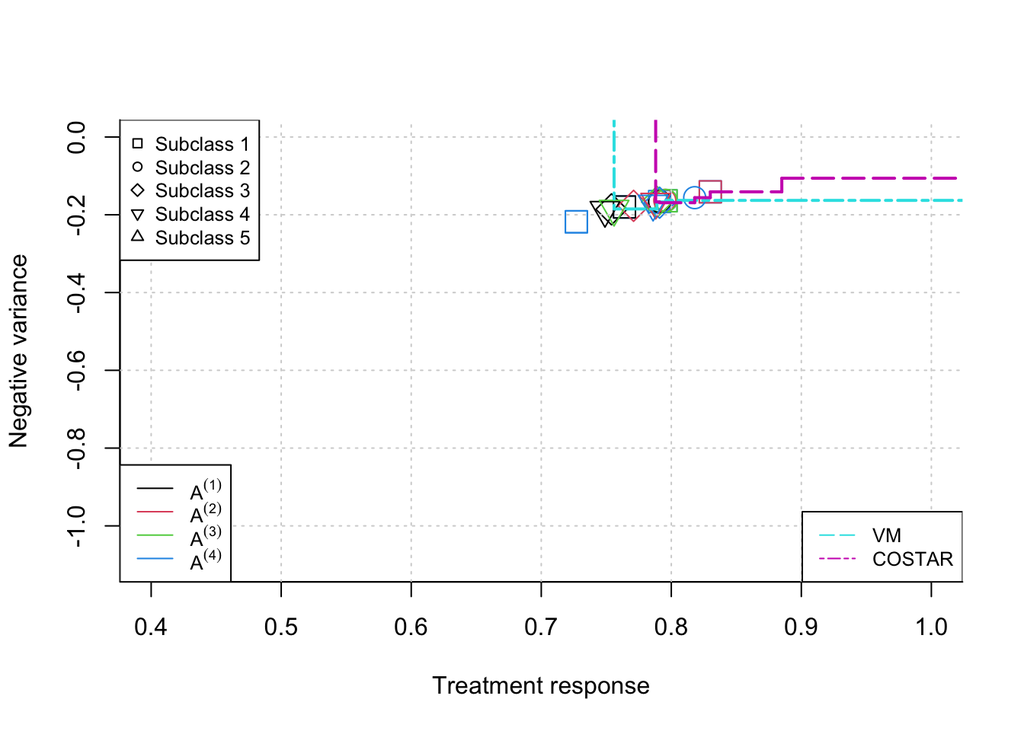

```
## NULL
##     mean    Var
## 2  0.830 -0.141
## 8  0.818 -0.156
## 12 0.791 -0.169
## 14 0.788 -0.167
## 20 0.885 -0.106
```

```
## [1] 0
```

```r
resp.negdf<-resp.df
resp.negdf$Var<-(-resp.negdf$Var)
opt.bmseneg<-opt.bmse
paretoplot5s(resp.negdf,opt.bmse)
```

```r
opt.bmse[,c(2:3)]
```

```
##   block treatment
## 1     1         2
## 2     2         4
## 3     3         4
## 4     4         2
## 5     5         4
```

```r
   pdf(file ="~/Downloads/Rpkg/cvmfd/man_ffd/pareto.pdf", width = 5, height = 4.8)
paretoplot5s(resp.negdf,opt.bmse)
```

```
## NULL
##     mean    Var
## 2  0.830 -0.141
## 8  0.818 -0.156
## 12 0.791 -0.169
## 14 0.788 -0.167
## 20 0.885 -0.106
```

```
## [1] 0
```

```r
 dev.off()
```

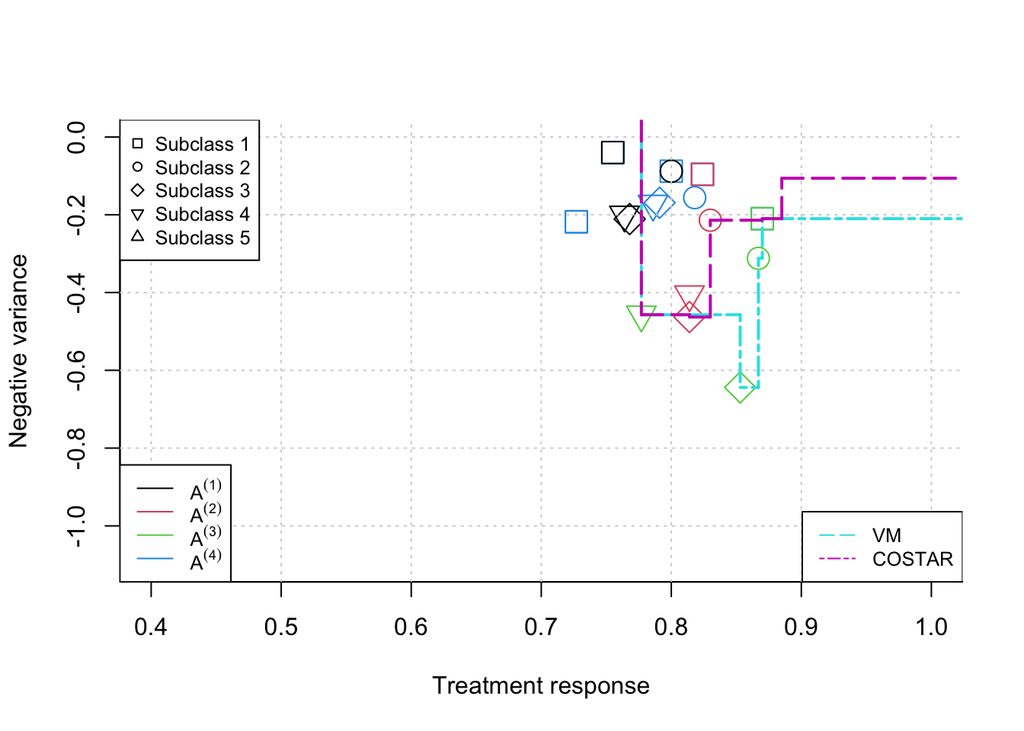

```
## NULL
##     mean    Var
## 3  0.870 -0.210
## 5  0.830 -0.214
## 8  0.814 -0.463
## 12 0.777 -0.457
## 20 0.885 -0.106
```

```
## [1] 0
```

```r
#####
mat.mean<-matrix(df.wgt$mean,nrow = 5, ncol = 4)
#mat.assign<-matrixassign(t(mat.mean))
mat.assign<-matrixassign5s((mat.mean))
df.sol<-mat.assign
#paretoplot(df.wgt,df.sol)
df.wgt<-data.frame(df.wgt)
#opt.bmse2<-df.wgt[df.wgt$Cell==df.sol$Cell,]
#opt.bmse<-df.wgt[c(1,7,10,16),]
opt.bmse<-df.wgt[c(3,6,10,15, 20),]
df.wgtneg<-df.wgt
df.wgtneg$Var<- (-df.wgtneg$Var)
opt.bmse2<-opt.bmse
opt.bmse2$Var<-(-opt.bmse2$Var)
paretoplot5s(df.wgtneg,opt.bmse2)
```

```r
   pdf(file ="~/Downloads/Rpkg/cvmfd/man_ffd/paretowt.pdf", width = 5, height = 4.8)
paretoplot5s(df.wgtneg,opt.bmse2)
```

```
## NULL
##     mean    Var
## 3  0.870 -0.210
## 5  0.830 -0.214
## 8  0.814 -0.463
## 12 0.777 -0.457
## 20 0.885 -0.106
```

```
## [1] 0
```

```r
 dev.off()
```

```r
#paretoplotpositive5s(df.wgtneg,opt.bmse2)
df.out<-df.sol[,c(2,4,1,3)]
library(xtable)
xtable(df.out)
```

```
## % latex table generated in R 4.0.2 by xtable 1.8-4 package
## % Mon May 24 09:18:39 2021
## \begin{table}[ht]
## \centering
## \begin{tabular}{rrrrr}
##   \hline
##  & block & Cell & objv & treatment \\
##   \hline
## 1 &   1 & 3.00 & 0.85 &   3 \\
##   2 &   2 & 6.00 & 0.87 &   2 \\
##   3 &   3 & 9.00 & 0.87 &   1 \\
##   4 &   4 & 15.00 & 0.81 &   3 \\
##   5 &   5 & 20.00 & 0.89 &   4 \\
##    \hline
## \end{tabular}
## \end{table}
```

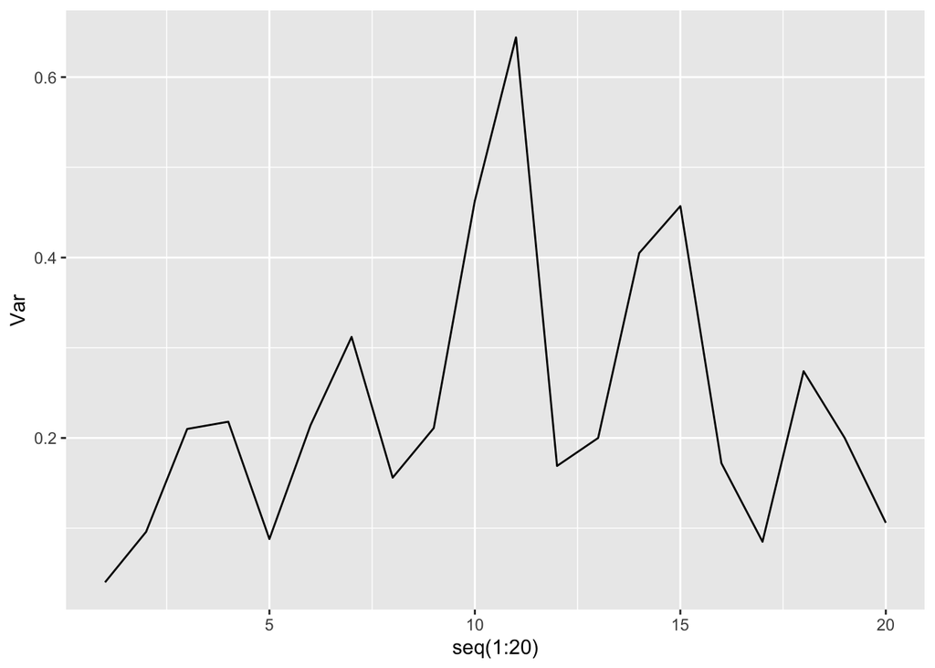

```r
ggplot(data=dat.mvar, aes(x=seq(1:20), y=Var))  +
    geom_line()
```

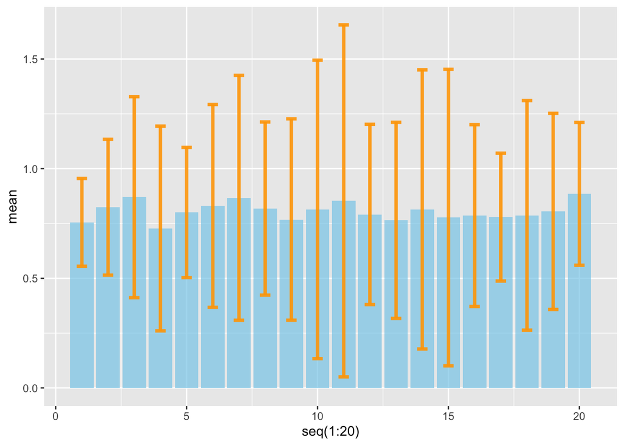

```r
# Most basic error bar
ggplot(dat.mvar) +
    geom_bar( aes(x=seq(1:20), y=mean), stat="identity", fill="skyblue", alpha=0.7) +
    geom_errorbar( aes(x=seq(1:20), ymin=mean-sqrt(Var), ymax=mean+sqrt(Var)), width=0.4, colour="orange", alpha=0.9, size=1.3)
```

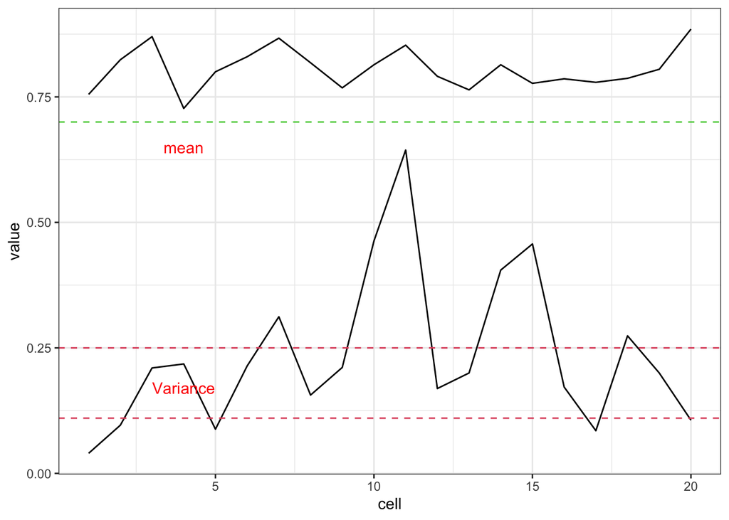

```r
ggplot(dat.mvar) +
    geom_line( aes(x=seq(1:20), y=mean))  +
    annotate(geom="text", x=4, y=0.65, label="mean",
              color="red")+
    geom_line( aes(x=seq(1:20), y=Var))  +
    annotate(geom="text", x=4, y=0.17, label="Variance",
              color="red")+
  xlab("cell") + ylab("value")+ labs(fill = "Response")+
  theme(legend.position="topright",legend.title = element_text(color = "blue", size = 10),
          legend.text = element_text(color = "red"))+
   geom_hline(yintercept = 0.25,  colour = c(2),lty=c(2))+
  geom_hline(yintercept = 0.11,  colour = c(2),lty=c(2))+
  geom_hline(yintercept = 0.7,  colour = c(3),lty=c(2))+
  theme_bw()
```